# Working with text

In this section, we’ll talk through the process of filtering data based on some free-form text. While this isn’t really “text analysis” its likely something that many of you will need to use if you’re interested in getting protest events centered around a specific topic.

### The CCC data

We’ll use data from the Crowd Counting Consortium (CCC). The CCC covers U.S. protest events from 2017 to the present, with new updates each week. These data are collected using a combination of webcrawling, social media analysis, and crowd-sourced contributions. The time frame and geographic scope is narrower compared to sources like ACLED, but they also tend to catch more events and offer a higher level of detail about each one.

You can access the CCC data from their [github site](https://github.com/nonviolent-action-lab/crowd-counting-consortium). Note that they have two separate files: one for events from 2017-2020 and a separate one for events from 2021 to the present. We’ll work with the 2021-Present file today.

- [Codebook](https://github.com/nonviolent-action-lab/crowd-counting-consortium/blob/master/ccc_data_dictionary.md)
- [Documentation](https://sites.google.com/view/crowdcountingconsortium/view-download-the-data)
- [Website](https://ash.harvard.edu/programs/crowd-counting-consortium/)

We’ll start by reading the data in and taking a look at our results

```r
library(tidyverse)

ccc<-read_csv('https://github.com/nonviolent-action-lab/crowd-counting-consortium/raw/refs/heads/master/ccc_compiled_2021-present.csv')


# view the first 10 rows:
ccc|>
  slice_head(n=10)
```

| date | locality | state | location_detail | online | type | title | macroevent | actors | organizations | participants | claims | valence | issues | issues_major | size_text | size_low | size_high | size_mean | size_cat | arrests | arrests_any | injuries_crowd | injuries_crowd_any | injuries_police | injuries_police_any | property_damage | property_damage_any | chemical_agents | participant_measures | … |
| --- | --- | --- | --- | --- | --- | --- | --- | --- | --- | --- | --- | --- | --- | --- | --- | --- | --- | --- | --- | --- | --- | --- | --- | --- | --- | --- | --- | --- | --- | --- |
| 2021-01-01 | Montgomery | AL | statewide | 0 | strike; boycott | NA | NA | Free Alabama Movement; prisoners | Free Alabama Movement | prisoners | against prison labor, for safer conditions in Alabama prisons during coronavirus pandemic | 1 | covid; criminal justice; labor | covid; criminal justice; labor | NA | NA | NA | NA | 0 | NA | 0 | NA | 0 | NA | 0 | NA | 0 | 0 | NA | … |
| 2021-01-01 | Tucson | AZ | E Speedway Blvd and N Euclid Ave | 0 | vigil | NA | NA | Women in Black | Women in Black | NA | for ending Israel's occupation of Palestine, for Palestinian liberation | 0 | foreign affairs | foreign affairs | NA | NA | NA | NA | 0 | NA | 0 | NA | 0 | NA | 0 | NA | 0 | 0 | NA | … |
| 2021-01-01 | Lafayette | CA | El Curtola Blvd & Highway 24 | 0 | demonstration | NA | NA | Contra Costa County Patriots | Contra Costa County Patriots | NA | for President Trump | 2 | presidency | presidency | NA | NA | NA | NA | 0 | NA | 0 | NA | 0 | NA | 0 | NA | 0 | 0 | NA | … |
| 2021-01-01 | Palo Alto | CA | El Camino Real and Embarcadero Rd | 0 | vigil | NA | NA | WILPF | WILPF | NA | for peace, against war, for banning nuclear weapons | 0 | military | military | NA | NA | NA | NA | 0 | NA | 0 | NA | 0 | NA | 0 | NA | 0 | 0 | NA | … |
| 2021-01-01 | Pasadena | CA | Rose Bowl Stadium | 0 | rally; parade | Patriots' Rose Parade | NA | Trump Unity Bridge SO CAL Events; Trump supporters | Trump Unity Bridge SO CAL Events | Trump supporters | for President Trump, against election fraud, against Governor Newsom, against state coronavirus mandates | 2 | covid; democracy; presidency | covid; democracy; presidency | as many as 1,000 vehicles | 1000 | 1000 | 1000 | 3 | NA | 0 | NA | 0 | NA | 0 | NA | 0 | 0 | NA | … |
| 2021-01-01 | San Francisco | CA | home of U.S. House of Representatives Speaker Nancy Pelosi, Pacific Heights | 0 | direct action | NA | NA | an autonomous multi-racial group of anarchists and radicals | NA | an autonomous multi-racial group of anarchists and radicals | for canceling rent and providing financial relief during coronavirus pandemic | 1 | banking and finance; covid; economy; housing | banking and finance; covid; economy; housing | NA | NA | NA | NA | 0 | NA | 0 | NA | 0 | NA | 0 | graffiti | 1 | 0 | NA | … |
| 2021-01-01 | San Francisco | CA | Civic Center Plaza | 0 | bicycle ride | NA | NA | San Francisco Bike Party | San Francisco Bike Party | NA | for safer streets for bicyclists, for community-building | 0 | transportation | transportation | NA | NA | NA | NA | 0 | NA | 0 | NA | 0 | NA | 0 | NA | 0 | 0 | NA | … |
| 2021-01-01 | San Jose | CA | Dr. Martin Luther King, Jr. Library, 150 E San Fernando St | 0 | vigil | Friday Night Peace Vigil | NA | NA | NA | NA | for peace | 0 | military | military | NA | NA | NA | NA | 0 | NA | 0 | NA | 0 | NA | 0 | NA | 0 | 0 | NA | … |
| 2021-01-01 | Santa Rosa | CA | Sonoma County Jail | 0 | hunger strike | NA | NA | inmates | NA | inmates | for free phone calls and video visitations and increased access to voluntary work assignments for prison inmates | 0 | criminal justice | criminal justice | 21.0 | 21 | 21 | 21 | 1 | NA | 0 | NA | 0 | NA | 0 | NA | 0 | 0 | NA | … |
| 2021-01-01 | Sherman Oaks | CA | Sherman Oaks Galleria, Sepulveda Blvd and Ventura Blvd | 0 | demonstration | NA | NA | The Valley of Change | The Valley of Change | NA | Black Lives Matter, against police brutality | 1 | policing; racism | policing | NA | NA | NA | NA | 0 | NA | 0 | NA | 0 | NA | 0 | NA | 0 | 0 | NA | … |

### Regular Expressions

The higher level of detail in the CCC can lead to some slightly “messy” data. For instance: many protest events involve more than one form of action. In order to capture this while still ensuring that each row of data represents a single event, the CCC will list every form used with each one separated by a semicolon:

```r
ccc|>
  slice_head(n=5)|>
  select(date, state, type)
```

| date | state | type |
| --- | --- | --- |
| 2021-01-01 | AL | strike; boycott |
| 2021-01-01 | AZ | vigil |
| 2021-01-01 | CA | demonstration |
| 2021-01-01 | CA | vigil |
| 2021-01-01 | CA | rally; parade |

What if we’re interested in demonstrations involving bicycle rides? We can use the `filter` function to catch cases where `type=='bicycle ride'` but this will miss events like the one below:

| date | location_detail | type |
| --- | --- | --- |
| 2022-08-08 | Los Angeles City Hall | protest; direct action; bicycle ride |

So, what we really want here is not a filter for `type=='bicycle ride'`, we want all cases where the `type` column contains the string “bicycle ride” anywhere. To get this, we can use the [`str_detect` function](https://stringr.tidyverse.org/reference/str_detect.html). `str_detect` will search a string of text for a pattern and return `TRUE` if the pattern is matched. If we use this to `filter` the CCC data, we can extract all cases where the string “bicycle ride” shows up. (try `View`-ing the data to see what this turns up.

```r
bike_string<-ccc|>
  # this gets any rows where the type column contains the pattern value:
  filter(str_detect(string = type, pattern = "bicycle ride"))
```

If you dig around a bit in the CCC data, you might notice a problem: there are some protest events where the event type is listed as “bike ride”. CCC coders are human, after all, and sometimes they’re not totally consistent on how to describe stuff.

Our pattern in the prior chunk will miss events that describe the protest as a “bike ride”, but we can fix this pretty easily by adding a “|” (pipe) to our pattern. The pipe here basically means OR, so you can read this as “Match either bicycle ride OR bike ride”.

```r
bike_string<-ccc|>
  # this gets any rows where the type column contains the pattern value:
  filter(str_detect(string = type, pattern = "bicycle ride|bike ride"))

nrow(bike_string)
```

```
[1] 1038
```

### Question 1

The `organizations` column also contains a semi-colon separated list of what organizations (if any) participated in a protest. What % of protest events involved the Proud Boys (note, in the last example I was using `filter`, but here I’m creating a new column based on the output of `str_detect`, so I need to use `mutate`

```r
# code to identify protests where proud boys participated and then get a proportion

ccc|>
# using na_replace to remove NA values from the organizations column
  mutate(proud_boys = str_detect(replace_na(organizations, ""), "Proud Boys"))|>
  count(proud_boys)|>
  mutate(proportion = n/sum(n))
```

| proud_boys | n | proportion |
| --- | --- | --- |
| FALSE | 133127 | 0.996504334 |
| TRUE | 467 | 0.003495666 |

### Complex patterns

The “pattern” argument for `str_detect` uses a Regular Expression Pattern (or RegExP). Regular expressions are a specialized language for matching strings of text, and they allow us to search for all sorts of complicated patterns using wild cards, negations, capture groups etc.

We won’t go too deep down this rabbit hole ([you can really do a lot with a regex!](https://github.com/nonviolent-action-lab/crowd-counting-consortium/blob/master/data_compilation/ccc_issue_regex_list.R)), but I do want to identify some basic operators that might be useful.

| Expression | Function |
| --- | --- |
| `\|` | logical “OR” operator. |
| `.` | Matches any character one time |
| `*` | Matches the previous character 0 to infinity times |
| `\b` (in r, you need `\\b`) | Matches a word boundary (a space, period, or end of the line) |
| `[A-Za-z]` `[0-9]` | The first matches any letter, the second matches any number from 0-9 |

If you’re testing out a regular expression, I recommend using [this site](https://regex101.com/), which lets you test different expressions interactively. Put several examples into the “test string” section and then try out different patterns and see what gets highlighted.

Lets look at a more complex example: what if I wanted information on protests related to transgender people or trans rights in the U.S.? The CCC includes a “claims” column that attempts to document the demands of protesters. An obvious approach might be to grab all cases that mention “trans”, but this will catch a lot of false positives because there are also protests about “public TRANSit” or “TRANSportation” or “TRANSfers of power”, so we would want to be careful about including that on its own.

| claims |
| --- |
| for continuing to provide airport service workers with discounted transportation pass |
| for release of all immigrant detainees, for abolishing ICE, against racism, for equal access to education and healthcare and housing and transportation and a clean environment, for good jobs, for soci… |
| against temporary closure of Somerset SEPTA station, for access to public transportation, against disinvestment in Kensington neighborhood |
| for extending electric passenger rail transportation in Santa Cruz County |
| for easier process for refunding rescinded county transportation tax |

Instead, I can use the expression `\\btrans\\b`. The `\b` pattern indicates a word boundary (space, punctuation mark, or beginning or end of a sentence), so this ensures that I will not capture cases where the pattern trans occurs as part of a term like “transit”.

```r
trans_protests<-ccc|>
  filter(str_detect(claims, "\\btrans\\b|transgender|drag show"))
```

### Question 2

Write a regular expression that matches the included phrases but not the excluded ones:

| Claim | Included? |
| --- | --- |
| in remembrance of victims of COVID-19 | Yes |
| against mandatory vaccines for Coronavirus | Yes |
| against HPV vaccination mandate for students | No |
| against mask mandates | Yes |
| for legislation banning masks from demonstrations | No |
| against covid restrictions | Yes |
| hate is the real virus | No |

```r
#

covid_protests<-ccc|>
  filter(str_detect(tolower(claims), "covid|coronavirus|mask mandate|fauci"))
```

### Making a timeline plot

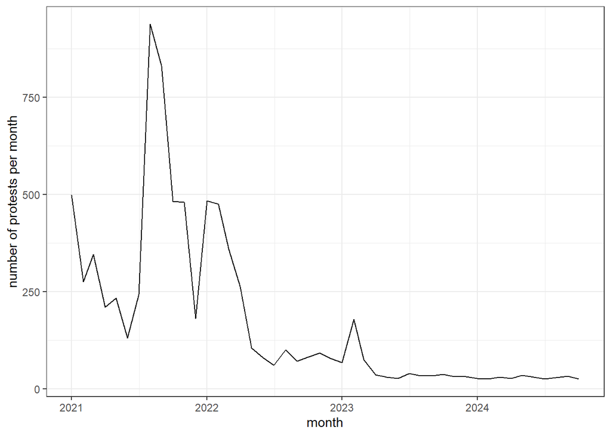

```r
monthly_covid_protests <- covid_protests|>
  mutate(month = floor_date(date, unit='month'))|>
  count(month)


ggplot(monthly_covid_protests, aes(x=month, y=n)) +
  geom_line() +
  theme_bw() +
  ylab("number of protests per month")
```

### Notes

- The CCC `issues` column summarizes the primary topic or topics for each event. This variable is itself created by [a series of complex regular expressions](https://github.com/nonviolent-action-lab/crowd-counting-consortium/blob/master/data_compilation/ccc_issue_regex_list.R).
- The same basic logic we used here could also be used to filter data from ACLED. In particular, the “notes” column from ACLED data will contain free-form text that you could use to zero in on protests around a specific topic.
- Several other CCC columns use this semi-colon separated language. If you’re interested in using this in your research, I strongly advise taking a look at the [data dictionary](https://github.com/nonviolent-action-lab/crowd-counting-consortium/blob/master/ccc_data_dictionary.md).
- Pay attention to the valence of protest events, in addition to their main issue or claims. If you’re interested in protests about abortion, you might want to consider writing an expression that can distinguish between events favoring abortion rights vs. events opposed to them. (the “claims” column will generally say whether an protesters are “for” or “against” something)